# Clustering (Proteomics/Transcriptomics inflammation biomarkers)

3 sept 25

# Loading libraries

```r
library(Seurat) # SeuratObject_4.1.3 Seurat_4.3.0.1
# library(Matrix)
library(data.table)
library(ComplexHeatmap)
library(RColorBrewer)
library(circlize)
library(dendsort)

set.seed(10)
library(glmnet)
library(tidyverse)
library(ggpubr)

source("src/function/functions.R")
source("src/function/loading_data.R")
```

# loading data

```r
## seurat
oshu <- readRDS("output/rds/oshu_seurat_obj.rds")
cluster <- oshu@active.ident

## other sampleinfo
sampleinfo2 <- read.csv("data/oshu/rnaseq_sampleinfo.csv", check.names = F)
rownames(sampleinfo2) <- sampleinfo2$Sample_ID
sampleinfo2$cohort <- factor(sampleinfo2$cohort)
sampleinfo2$cluster <- cluster

## inflammation
inflammatory_sig_genes <- readRDS("data/inflammatory_sig_genes.rds")
```

# tbl 24: filtering for biomarkers

steps before this - select concordantly regulated genes C3, C7 - find the correlation between rna and protein

c3/c7; corr rna prot > 0.5 (261->>258); HVG (258 -> 147); hub genes (147 -> 55)

```r
# correlation between rna and prot
corr_df <- read.csv("output/oshu_corr_global_prot_rna_per_gene.csv")

data <- read.csv("output/oshu_rna_prot_overlap.csv")
selected_gene <- data[data$category_no %in% c("C3", "C7"),]  %>%
  filter(Gene %in% corr_df$Gene[corr_df$cor >= 0.5]) # 261->>258
```

- filtering for hub genes (as well as restricting to HVG)
  - adjacency is based on connection strength (sum of edge weights), while WGCNA’s kME (module eigengene-based connectivity) measures correlation with the module eigengene.
  - Both are measures of intramodular importance: Genes ranked high by adjacency tend to also have high kME.
- looking at WGCNA modules -> selecting hub genes

```r
hub_genes <- read.csv("output/oshu_wgcna_module_genes.csv")[1:4]

gene_anno <- read.csv("data/baml/filtered_gene_baml_rnaseq.csv")[c(1:2,3,8)]
df <- hub_genes %>%
  filter(gene %in% selected_gene$Gene,          # to get 147 genes
         kME > 0.8) %>%                         # to get 55 genes
  left_join(gene_anno, by=c("gene" = "gene_name")) %>%
  left_join(selected_gene[,c(1,10)], by=c("gene" = "Gene") ) %>%
  mutate(in_inflam = gene_id %in% inflammatory_sig_genes$GeneID)

write.csv(df, "output/oshu_biomarkers.csv", row.names = F)
```

# loading data for elastic net regression

- concordantly regulated gene 261 -> good corr between rna and prot 258 -> hub genes + HVG 55
- only focusing on the top combinations (with median CR < 1) - 78/89

```r
## selected proteins: genes & proteins that are both upregulated in inflam clusters
biomarker <- read.csv( "output/oshu_biomarkers.csv")

## filtering genes correlated with top performing combination
topcombi <- read.csv("output/oshu_combinationindex.csv") %>% # (89)
  filter(median_CR <= 1) %>%
  mutate(combo = Combination,
         Combination = gsub("[ -]", ".", Combination))

## transcriptomics
transcript <- readRDS("data/oshu/rnaseq_vst.rds") %>%
  filter(GeneID %in% biomarker$gene_id) %>%
  select(Gene, oshu@meta.data$Sample_ID) %>%
  column_to_rownames("Gene")

X <- t(transcript)  # make sure it's a matrix
X_long <- reshape2::melt(X, na.rm = T)
colnames(X_long) <- c("lab_id", "Gene", "Expression")

## drug response
Y_all <- oshu@meta.data[, colnames(oshu@meta.data) %in% topcombi$Combination] # 89 -> 78
Y_long <- reshape2::melt(t(Y_all), na.rm = T)
colnames(Y_long) <- c("Combination", "lab_id", "DSS")
```

## suppfig 8: plot schematics

```r
hm_x5 <- Heatmap(t(X), rect_gp = gpar(col = "black", lwd=0.00001),
                cluster_rows = F, cluster_columns = F,
                show_row_names = F, show_column_names = F, show_heatmap_legend = F,
                row_title = "Selected genes\n(n=55)", row_title_rot = 0,
                column_title = "Samples (n=341)",
                width = unit(3, "in"), height = unit(0.02* 55, "in")
                )

hm_y <- Heatmap(t(Y_all), rect_gp = gpar(col = "black", lwd=0.00001),
                col= colorRamp2(seq(0,1,by=0.1), viridis::viridis(n=11)),
                cluster_rows = F, cluster_columns = F,
                show_row_names = F, show_column_names = F, show_heatmap_legend = F,
                row_title = "Combination\n(n=78)", row_title_rot = 0,
                width = unit(3, "in"),
                height = unit(0.02* 78, "in")
                )

ht_list = hm_x5 %v% hm_y

png("plot/suppfig8/elasticnet_schematic.png", res=600, width = 5, height = 5, units = "in")
draw(ht_list, row_title_gp = gpar(fontsize = 14))
```

# setting up elastic net regression

- using elastic net to get sparse but stable models
- identifying genes important to predicting combinations

```r
library(glmnet)
set.seed(10)

results <- list()
fixed_alpha <- 0.5  # Elastic Net blend: equal parts Lasso and Ridge
group <- oshu@meta.data[, c("Sample_ID", "patientId")]

for (i in seq_len(ncol(Y_all))) {
  cb <- colnames(Y_all)[i]
  y <- Y_all[, i]
  valid_idx <- complete.cases(y)
  y <- y[valid_idx]
  x <- X[valid_idx, ]

  group_ <- group[valid_idx,]
  unique_groups <- unique(group_$patientId)
  n_groups <- length(unique_groups)

  group_fold_assignments <- sample(cut(seq(1, n_groups), breaks = 5, labels = FALSE))
  names(group_fold_assignments) <- unique_groups
  group_$fold <- group_fold_assignments[as.character(group_$patientId)]

  # Fit Elastic Net with fixed alpha
  cvfit <- cv.glmnet(x, y, alpha = fixed_alpha, family = "gaussian", foldid = group_$fold, type.measure="mse")

  # Extract coefficients at lambda.min
  coef_tbl <- coef(cvfit, s = "lambda.min")
  coef_df <- data.frame(
    feature = rownames(coef_tbl),
    coef = as.numeric(coef_tbl)
  ) |> subset(feature != "(Intercept)")

  # extracting performance
  y_pred <- predict(cvfit, newx = x, s = "lambda.min")[,1]


  results[[cb]] <- list(
    model = cvfit,
    x_val = x,
    y_val = y,
    y_pred = y_pred,
    coefs = coef_df,
    combo = cb,
    alpha = fixed_alpha,
    n = length(y),
    lambda = cvfit$lambda.min,
    cv_perf = min(cvfit$cvm), # minimum MSE for best lambda
    pearson = cor(y, y_pred),
    spearman = cor(y, y_pred, method = "spearman"),
    spearmanP = signif(cor.test(y, y_pred, method = "spearman", continuity = T, alternative = "greater")$p.value, 5),
    kendall = cor(y, y_pred, method = "kendall"),
    kendallP = signif(cor.test(y, y_pred, method = "kendall", exact = T, continuity = T, alternative = "greater")$p.value, 5),
    rsq = r_squared(y, y_pred),
    pred_sd = sd(y_pred)
  )
}
```

```
Error in r_squared(y, y_pred) : could not find function "r_squared"
```

# tbl 25: outcomes of elastic net

- focusing on being models that are able to capture some variance in drug response
- filtering out poor models (unfit model)
  - models with no gene coeff
  - models with poor r^2 (coef of determination) == squared pearson’s r - explains variance of the predictions
    - spearman > 0.5
    - rsq > 0.1 (r^2 = 0.25; moderate fit) - to remove all those that are not better than mean/explains less than 10% variance
  - (not used) models with poor variance/SD (very tight range on their prediction)
    - sd < 0.05 (values are clustered in a small range e.g. 0.48-0.52)

```r
results <- readRDS("output/rds/biomarkers_elasticnet.rds")
Y_all <- oshu@meta.data[, colnames(oshu@meta.data) %in% topcombi$Combination] # 89 -> 78
ref="Azacitidine...Venetoclax"
```

## performance

- Combination (n = 78)
  - 18 combinations with 0 coeff for genes

```r
# summarise
perf_summary <- do.call(rbind, lapply(results, function(r) {
  data.frame(
    combo    = listofnames[r$combo],
    alpha    = r$alpha,  # use 'alpha' instead of 'best_alpha'
    n        = r$n,
    lambda   = r$lambda,
    cv_perf  = r$cv_perf,
    n_genes  = sum(r$coefs$coef != 0),
    pearson  = r$pearson,
    spearman = r$spearman,
    spearmanP = r$spearmanP,
    kendall  = r$kendall,
    kendallP = r$kendallP,
    rsq      = r$rsq,
    pred_sd  = r$pred_sd
  )
})) %>%
  mutate(selected = spearman > 0.5 & n_genes > 0 & rsq > 0.1)

write.csv(perf_summary, "output/supp/elasticnet_perf_summary.csv", row.names = F)

## saving the coefs of each model
coef_long <- do.call(rbind, lapply(results, function(r) {
  data.frame(
    combo = listofnames[r$combo],
    feature = r$coefs$feature,
    coef = r$coefs$coef
  )
}))
write.csv(coef_long, "output/supp/biomarkers_elasticnet_long.csv", row.names = F)

coef_wide <- reshape2::dcast(coef_long, combo ~ feature, value.var = "coef", fill = 0) %>%
  left_join(perf_summary)

write.csv(coef_wide, "output/biomarkers_elasticnet_summary.csv", row.names = F)
```

# plot

- remember to load loading data and loading data for elastic net regression

filtering out models - 18/78 had no coeff - 20/78 failed evaluation - 40/78 passed

```r
results <- readRDS("output/rds/biomarkers_elasticnet.rds")
Y_all <- oshu@meta.data[, colnames(oshu@meta.data) %in% topcombi$Combination] # 78
ref="Azacitidine...Venetoclax"

perf_summary <- read.csv("output/supp/elasticnet_perf_summary.csv")
coef_long <- read.csv("output/supp/biomarkers_elasticnet_long.csv")
coef_wide <- read.csv("output/biomarkers_elasticnet_summary.csv")

perf_summary_filt <- perf_summary %>%
  filter(spearman > 0.5, n_genes > 0, rsq > 0.1)

# table(spearman = perf_summary$spearman > 0.5, rsq = perf_summary$rsq > 0.1, n_genes = perf_summary$n_genes  != 0, useNA = "ifany")
```

## fig 7e: heatmap on the coefficient (40 models)

- table(rowSums(coef_wide) != 0) # 1 gene with 0 coeff - PGLYRP1
- range(colSums(coef_wide != 0)) # each model has 1 - 33 coeffs
- rowSums(coef_wide != 0) %>% sort

PGLYRP1 CDA ARG1 LGALS3 LILRA6 MMP8 C5AR1 CYP4F3 MGAM S100P 0 1 2 4 4 4 5 5 5 5 SAMHD1 ANXA3 CEACAM8 FCAR FCGR2A FGR LILRB4 LTF S100A12 S100A8 5 6 6 6 6 6 6 6 6 6 FCER1G PADI2 RBM47 S100A9 BPI CTSH MMP9 PADI4 SCPEP1 CKAP4 7 7 7 7 8 8 8 8 8 9 FBP1 LRRC25 NCF2 VCAN PTPRJ SLC2A3 CD14 FGD2 HP MEFV 9 9 9 9 10 10 11 11 11 11 POU2F2 FCGRT FCN1 ITPRIP MPEG1 TYMP CD4 FGL2 LRP1 ANXA5 11 12 12 12 12 12 13 13 13 14 LILRB1 SLPI GCA TUBA4A KCTD12 14 14 15 17 20

```r
## correlation with
oshu <- readRDS("output/rds/oshu_seurat_obj.rds")
df <- .run.cor(oshu@meta.data[,c(271:277,280)], oshu@meta.data[,78:270], method = "spearman", min.n = 5) %>%
  mutate(Combination = listofnames[Combination])  %>%
  filter(Combination %in% perf_summary_filt$combo,
         Group == "inflammatory_sig_genes") %>%
  select(Combination, cor) %>% column_to_rownames("Combination")

coef_long <- coef_long %>%
  filter(combo %in% perf_summary_filt$combo)
coef_wide <- reshape2::acast(coef_long, feature ~ combo, value.var = "coef", fill = 0)
```

```r
mat <- coef_wide[rowSums(coef_wide) != 0, colSums(coef_wide) != 0 ]
mat <- mat[, colSums(mat != 0) %>% sort %>% names()]

col_fun <- colorRamp2(c(0.50, 0.75, 1.00), brewer.pal(3, "YlGn"))

row_ha = rowAnnotation(
  "CorrCoeff w \nInflam sig" = df[colnames(coef_wide),],
  col=list(
    "CorrCoeff w \nInflam sig" = colorRamp2(c(-0.7, 0, 0.7), c("#4d9220", "grey95", "#c5247d"))
           ),
  gp = gpar(col = "white", lwd=0.2) )

hm <- Heatmap(t(mat), name = "ElasticNet\nCoeff",
  rect_gp = gpar(col = "white", lwd=1), border = T,
  right_annotation = row_ha,
  row_split = df[colnames(coef_wide),] > 0,
  col = colorRamp2(c(-0.05, -0.025, -0.005, 0, 0.005, 0.025, 0.05), c("#2166AC", "#4393C3" , "#92C5DE", "grey95", "#F4A582", "#D6604D", "#B2182B")),
  clustering_distance_rows = "pearson",
  column_title = NULL, row_title = NULL,
  row_dend_reorder = T, column_dend_reorder = T,
  show_row_dend = T, show_column_dend = T,
  width = unit(0.15*nrow(mat), "in"),
  height = unit(0.15*ncol(mat), "in")
)

png("plot/fig7/main_7e_elasticnet_hm.png", width = 0.15*nrow(mat) + 5, height = 0.15*ncol(mat) + 3, units = "in", res=600, family = "Arial", bg = "transparent")
# Cairo::CairoPDF("plot/fig7/main_7e_elasticnet_hm.pdf", width = 0.15*nrow(mat) + 5, height = 0.15*ncol(mat) + 3, bg = "transparent", family = "Arial")

ComplexHeatmap::draw(hm, merge_legends = T, background = "transparent")
```

# VenAza

```r
selected <- results[["Azacitidine...Venetoclax"]]
model <- selected$model
selected_coef <- selected$coefs %>% left_join(biomarker[4:5], by=c("feature"="gene"))
```

```r
df <- data.frame("Observed_DSS" = selected$y_val, "Predicted_DSS" = selected$y_pred)

p <- ggscatter(df, x= "Observed_DSS", y="Predicted_DSS",
          add = "reg.line", cor.coef = T, cor.method = "spearman",
          xlim = c(0,1), ylim = c(0,1)) +
  theme(aspect.ratio = 1) + theme_pdf

ggsave(plot = p, "plot/suppfig9/suppfig_9a_elasticnet_venaza.png", dpi=600, width = 5, height = 5)
ggsave(plot = p, "plot/suppfig9/suppfig_9a_elasticnet_venaza.pdf", width = 5, height = 5, bg = "transparent", device = cairo_pdf)
```

```r
## protein
global_proteomics <- read.csv("data/oshu/global_proteomics.csv", check.names = F, row.names = 1) %>% t()
df <- data.frame("Sample_ID" = names(selected$y_pred),
                 "Observed_DSS" = selected$y_val,
                 "Predicted_DSS" = selected$y_pred) %>%
  filter(Sample_ID %in% rownames(global_proteomics)) %>%
  mutate(cluster = cluster[Sample_ID],
         cluster = ifelse(cluster %in% c(1,3,5), "inflam low", "inflam high"))

venaza_coeff <- selected_coef$feature[selected_coef$coef != 0]
df <- cbind(df, global_proteomics[df$Sample_ID, venaza_coeff ]) %>%
  pivot_longer(cols = 5:13, names_to = "Gene", values_to = "Relative_abundance")

## spearman correlation
statstest <- df %>% group_by(Gene) %>% rstatix::cor_test(Observed_DSS, Relative_abundance, method = "spearman") %>% rstatix::adjust_pvalue(method = "fdr")

statstest <- statstest %>%
  mutate(
    pval_fmt = scales::pvalue(p.adj, accuracy = 0.0001, add_p = TRUE),
    pval_fmt = case_when(
      grepl("p < ", pval_fmt) ~ gsub("p < ", "italic(p)~`<`~", pval_fmt, fixed = TRUE),
      grepl("p = ", pval_fmt) ~ gsub("p = ", "italic(p)~`=`~", pval_fmt, fixed = TRUE),
      TRUE ~ paste0("italic(p)==", signif(p.adj, 3))  # fallback
    ),
    # Combine into final label
    label = paste0("italic(R)==", cor, '*","~', pval_fmt)
  )

## plot
p <- ggplot(df, aes(x=Relative_abundance, y=Observed_DSS, colour=cluster)) +
  geom_smooth(method = "lm", color = "grey30", se = F) +
  geom_point(size=2, alpha = .8) +
  scale_color_brewer(palette="Set1") +
  labs(y="DSS of VenAza", x="Relative protein abundance")+
  geom_text(data=statstest, mapping = aes(x = -Inf, y = 1.1, label = label), color="black", size=3, parse = T, hjust = -0.05) +
  scale_y_continuous(expand = c(0.1, 0.1)) +
  scale_x_continuous(expand = c(0.1, 0.1)) +
  facet_wrap(~Gene, ncol = 5, nrow = 3, scales = "free_x") +
  theme_classic() +
  theme(aspect.ratio = 1.2, panel.border = element_rect(colour = "black", fill=NA, linewidth=1)) +
  theme_pdf

ggsave(plot = p, "plot/suppfig9/suppfig_9b_venaza_prot.png", width = 9, height = 6, dpi=600)
ggsave(plot = p, "plot/suppfig9/suppfig_9b_venaza_prot.png", width = 9, height = 6, bg = "transparent", device = cairo_pdf)
```

```r
## clinical response
temp <- read.csv("data/oshu/oshu_clinical_outcome_venaza.csv") %>%
  filter(dbgap_rnaseq_sample != "")

## gene expression
x <- readRDS("data/oshu/rnaseq_vst.rds") %>%
  filter(GeneID %in% selected_coef$gene_id) %>%
  select(Gene, temp$labId) %>%
  column_to_rownames("Gene") %>%
  t()

## predicted response
temp$predicted_DSS <- predict(model, newx = x, s = selected$lambda)[,1]

selected_coef <- selected_coef %>%
  arrange(coef) %>%
  mutate(sign = sign(coef)) %>%
  filter(coef != 0)

clinc_df <- x[,selected_coef$feature] %>% as.data.frame()
clinc_df$ResponseToVenAza <- temp$responseToInductionTx
clinc_df$Predicted_DSS <- temp$predicted_DSS
```

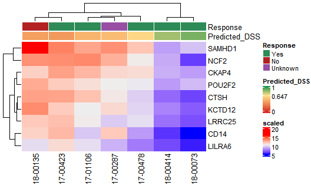

```r
mat <- t(clinc_df[1:nrow(selected_coef)])

col_ha1 = columnAnnotation(
  Response = clinc_df$ResponseToVenAza,
  Predicted_DSS = clinc_df$Predicted_DSS,
  col=list(
    Response = c("Complete Response"= "seagreen", "Unknown" = "#984EA3", "Refractory" = "firebrick"),
    Predicted_DSS = colorRamp2(c(0, 0.647, 1.00), c("#d73027", "#fee08b", "#1a9850"))
           ),
  annotation_legend_param = list(
    Predicted_DSS = list(at=c(0, 0.647, 1), legend_height = unit(1.5, "cm")),
    Response = list(labels=c("Yes", "No", "Unknown"))
    ),
  gp = gpar(col = "white", lwd=0.2) )

hm <- Heatmap(mat,
    show_row_names = T, show_column_names = T,
    row_names_gp = gpar(fontsize = 11),
    name = "scaled", heatmap_legend_param = list(legend_height = unit(1, "cm")),
    top_annotation = col_ha1)

# png("plot/fig7/main_7g_biomarkers_gene_exp.png", width = 5, height = 4, units = "in", res=600, family = "Arial", bg = "transparent")
# Cairo::CairoPDF("plot/fig7/main_7g_biomarkers_gene_exp.pdf", width = 5, height = 4, bg = "transparent", family = "Arial")
draw(hm, merge_legends = T, background = "transparent")
```

# clinical relevance

## suppfig 8c: ROC-AUC

```r
library(pROC)
df <- read.csv("data/all_clinical_response.csv", check.names = F)
x <- df

roc1 <- roc(data=x, response="Clinical_Response", predictor="Actual", algorithm=1) # calculate sens, 1-spec, auc score

thres = coords(roc1, "best", ret = "threshold")[,1] # prints best DSS threshold = 0.647
thres

# png("plot/suppfig8/supp_8c_roc_clinical.png", width = 5.9, height = 4.7, units = "in", res = 600, family = "Arial", bg = "transparent")
Cairo::CairoPDF("plot/suppfig8/supp_8c_roc_clinical.pdf", width = 5.9, height = 4.7, bg = "transparent", family = "Arial")
par(pty = "s")
plot.roc(roc1, main="ROC curve", legacy.axes=T, print.thres = T,
         print.auc=TRUE, col="black", asp=NA )
dev.off()
```

## suppfig 8c: confusion matrix

```r
x$Predict <- factor(ifelse(x$Actual > thres, 1, 0))
x$Clinical_Response <- factor(ifelse(x$Clinical_Response == "Responder", 1, 0))
confusion_matrix <- table(x$Predict, x$Clinical_Response)
TN <- confusion_matrix[1, 1]  # True negative
FN <- confusion_matrix[1, 2]  # False negative
FP <- confusion_matrix[2, 1]  # False positive
TP <- confusion_matrix[2, 2]  # True positive

specificity <- TN / (TN + FP)
sensitivity <- TP / (TP + FN)
PPV <- TP / (TP + FP)
FPV <- TN / (TN + FN)

print(sensitivity)
print(specificity)
print(PPV)
print(FPV)

table <- data.frame(caret::confusionMatrix(x$Predict, x$Clinical_Response)$table)

plotTable <- table %>%
  mutate(goodbad = ifelse(table$Prediction == table$Reference, "True", "False")) %>%
  dplyr::rename(Actual = Reference) %>%
  group_by(Actual) %>%
  mutate(prop = Freq/sum(Freq))

p <- ggplot(data = plotTable, mapping = aes(x = Prediction, y = Actual, fill = Freq)) +
  geom_tile() +
  scale_y_discrete(limits = c(0, 1)) +
  scale_x_discrete(limits = c(1, 0)) +
  geom_text(aes(label = Freq), vjust = .5, fontface  = "bold", alpha = 1, size=8) +
  scale_fill_gradient(low = "white", high = "#4682B0") +
  theme_void() +
  theme(legend.position="none") + theme_pdf


ggsave(plot = p, "plot/suppfig8/supp_8c_confusionM_clinical.png", width = 4, height = 4, dpi=600)
ggsave(plot = p, "plot/suppfig8/supp_8c_confusionM_clinical.pdf", width = 4, height = 4, bg = "transparent", device = cairo_pdf)
```

## boxplot

```r
plot <- df %>%
  ggplot(., aes(x=Clinical_Response, y=Actual, fill=Clinical_Response)) +
  stat_summary(fun.y=mean,fun.ymin = mean, fun.ymax = mean, geom="crossbar", color = "black", width=0.5) +
  stat_compare_means(method = "wilcox.test", label.x.npc = "centre") +

  geom_jitter(aes(shape=Dataset), position=position_jitter(0.25),
              size = 3, alpha=0.8) +
  scale_fill_manual(values = c("firebrick", "seagreen"), guide=NULL) +
  scale_shape_manual(values = c(21, 24), name="Dataset") +
  geom_hline(yintercept = thres, color="black", linetype="dashed") +
  annotate("text", label = "0.647",
           x = 2.45, y = thres+0.03, colour = "black" ) +
  ylim(c(0,1)) +
  labs(x="Clinical Response", y="DSS") +
  theme_classic(base_size = 14) +
  theme(legend.position="top", aspect.ratio = 1) +
  theme_pdf

plot

ggsave(plot = plot, "plot/fig7/main_7f_clinical_stats.png", width = 12, height = 11, dpi=600, units = "cm")
```

[figure not shown]

```r
ggsave(plot = plot, "plot/fig7/main_7f_clinical_stats.pdf", width = 12, height = 11, units = "cm", bg = "transparent", device = cairo_pdf)
```